# Reproducible Research: Peer Assessment 1

### Overview

It is now possible to collect a large amount of data about personal movement using activity monitoring devices. Data was analyzed from one such device which collected data at 5 minute intervals through out the day during the months of October and November, 2012, and include the number of steps taken in 5 minute intervals each day.

### Loading and preprocessing the data

The working directory was set, the required packages were uploaded and data downloaded.

```r
setwd("C:/Users/Henry/Documents/Rworkingdirectory/Reproducable_Research/Project_1")
##require(utils)
library(dplyr)
library(ggplot2)
library(tidyr)
library(lubridate)
library(xtable)
library(knitr)
library(gridExtra)
url <- "https://d396qusza40orc.cloudfront.net/repdata%2Fdata%2Factivity.zip"
fileLocation <- "C:/Users/Henry/Documents/Rworkingdirectory/Reproducable_Research/Project_1/repdata_data_activity.zip"
if (!file.exists(fileLocation)){
  download.file(url, fileLocation)
}
extractedFile <- unzip(fileLocation, overwrite=TRUE)
activity <- read.csv(extractedFile)
activity$date <- as.POSIXct(activity$date)
```

### What is mean total number of steps taken per day?

1. The total number of steps taken per day was calculated, and is presented below.

```r
sumDailySteps <- select(activity, steps, date) %>%
            na.omit() %>%
            group_by(date) %>%
            summarise(steps = sum(steps))%>%
            as.data.frame()
kable(sumDailySteps)
```

| date | steps |
| --- | --- |
| 2012-10-02 | 126 |
| 2012-10-03 | 11352 |
| 2012-10-04 | 12116 |
| 2012-10-05 | 13294 |
| 2012-10-06 | 15420 |
| 2012-10-07 | 11015 |
| 2012-10-09 | 12811 |
| 2012-10-10 | 9900 |
| 2012-10-11 | 10304 |
| 2012-10-12 | 17382 |
| 2012-10-13 | 12426 |
| 2012-10-14 | 15098 |
| 2012-10-15 | 10139 |
| 2012-10-16 | 15084 |
| 2012-10-17 | 13452 |
| 2012-10-18 | 10056 |
| 2012-10-19 | 11829 |
| 2012-10-20 | 10395 |
| 2012-10-21 | 8821 |
| 2012-10-22 | 13460 |
| 2012-10-23 | 8918 |
| 2012-10-24 | 8355 |
| 2012-10-25 | 2492 |
| 2012-10-26 | 6778 |
| 2012-10-27 | 10119 |
| 2012-10-28 | 11458 |
| 2012-10-29 | 5018 |
| 2012-10-30 | 9819 |
| 2012-10-31 | 15414 |
| 2012-11-02 | 10600 |
| 2012-11-03 | 10571 |
| 2012-11-05 | 10439 |
| 2012-11-06 | 8334 |
| 2012-11-07 | 12883 |
| 2012-11-08 | 3219 |
| 2012-11-11 | 12608 |
| 2012-11-12 | 10765 |
| 2012-11-13 | 7336 |
| 2012-11-15 | 41 |
| 2012-11-16 | 5441 |
| 2012-11-17 | 14339 |
| 2012-11-18 | 15110 |
| 2012-11-19 | 8841 |
| 2012-11-20 | 4472 |
| 2012-11-21 | 12787 |
| 2012-11-22 | 20427 |
| 2012-11-23 | 21194 |
| 2012-11-24 | 14478 |
| 2012-11-25 | 11834 |
| 2012-11-26 | 11162 |
| 2012-11-27 | 13646 |
| 2012-11-28 | 10183 |
| 2012-11-29 | 7047 |

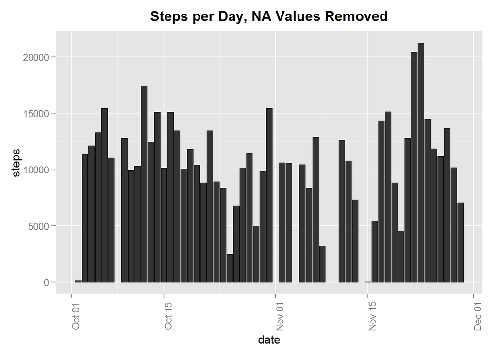

```r
DailyStepsPlot <- ggplot(sumDailySteps, aes(date, steps)) +
        geom_bar(stat="identity", position="dodge", color = "black", size=0.2)+
        ggtitle("Steps per Day, NA Values Removed")+
        theme(plot.title = element_text(face = "bold", vjust = 1.5),
              axis.text.x = element_text(angle = 90))
DailyStepsPlot
```

3. The mean and median number of steps per day was then calculated.

```r
MMDailySteps <- select(activity, steps, date) %>%
          na.omit() %>%
          group_by(date) %>%
          summarise(steps = sum(steps))
mean <- as.numeric(summarise(MMDailySteps, steps = mean(steps)))
median <- as.numeric(summarise(MMDailySteps, steps = median(steps)))
MM <- data.frame(mean, median, stringsAsFactors=FALSE)
kable(MM)
```

| mean | median |
| --- | --- |
| 10766.19 | 10765 |

### What is the average daily activity pattern?

1. A time series plot was made of the 5-minute interval and the average number of steps taken per day, averaged accross all days.

```r
FiveMinInterval <- select(activity, steps, interval) %>%
          na.omit() %>%
          group_by(interval) %>%
          summarise(steps = mean(steps))%>%
          as.data.frame()
```

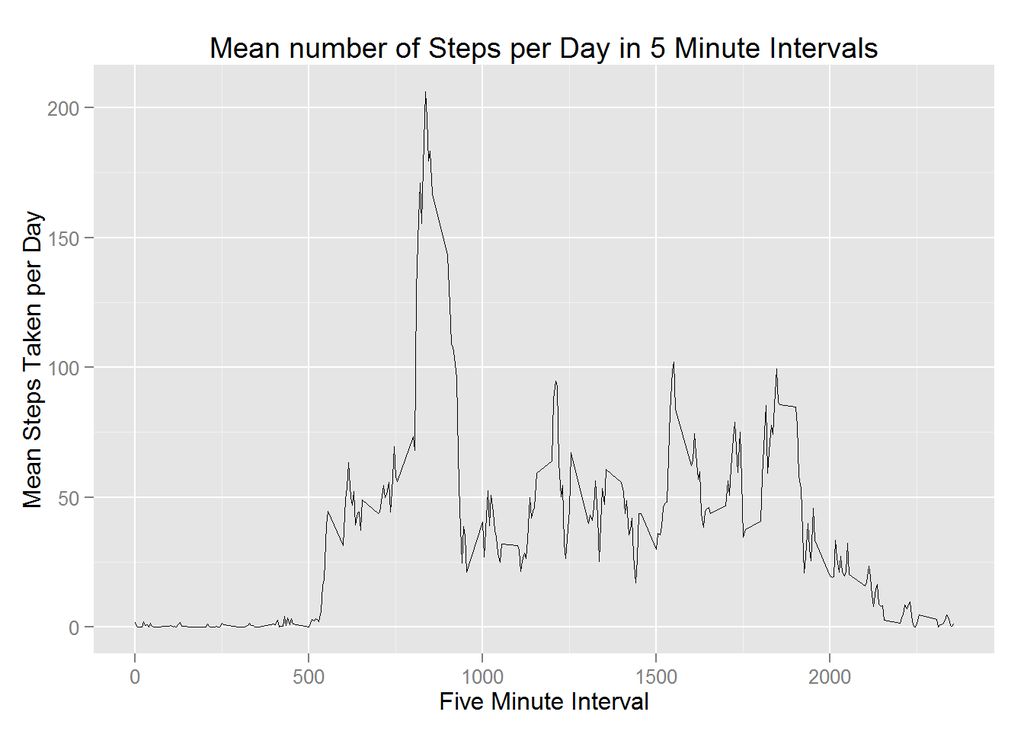

```r
TimeSeriesPlot1 <- FiveMinInterval %>% ggplot +
          geom_line(aes(interval, steps), stat="identity", position="dodge", colour="black", size=0.2) +
          ggtitle("Mean number of Steps per Day in 5 Minute Intervals") +
          xlab("Five Minute Interval") +
          ylab("Mean Steps Taken per Day")
TimeSeriesPlot1
```

2. The five minute interval with the most number of steps averaged acrross all days evaluate, and is presented with the corresponding maximum average number of steps.

```r
FiveMinIntervalMax <- filter(FiveMinInterval, steps == max(steps))
kable(FiveMinIntervalMax)
```

| interval | steps |
| --- | --- |
| 835 | 206.1698 |

## Imputing missing values

1. The total number of missing values was calculated to be 2304.

```r
missingValues <- activity %>%
          complete.cases %>%
        table
unname(missingValues[1])
```

```
## [1] 2304
```

2. (Includes part 3)The missing data was filled in using the mean of the corresponding interval.

```r
activityAdjustedNA <- activity %>%
          left_join(FiveMinInterval %>% select(interval, steps.average = steps), by = "interval") %>%
          mutate(steps.average = ifelse(is.na(steps), round(steps.average), steps)) %>%
          select(interval, date, steps.average) %>%
          rename(steps = steps.average)
```

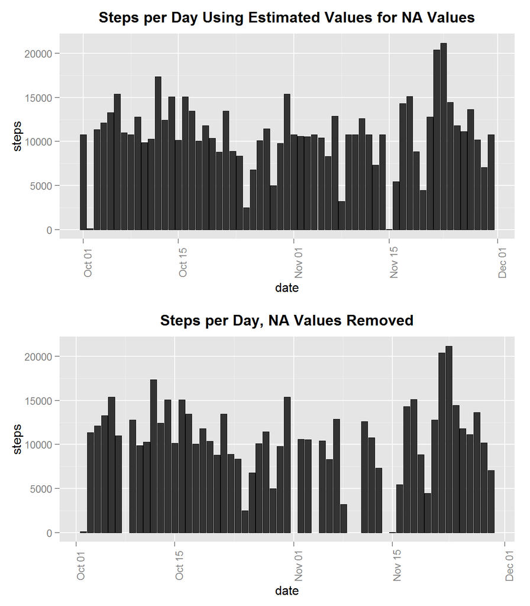

```r
DailyStepsAdjusted <- select(activityAdjustedNA, steps, date)
DailyStepsAdjusted <- DailyStepsAdjusted %>%
          na.omit() %>%
          group_by(date) %>%
          summarise(steps = sum(steps))

AdjustedDailyStepsPlot <- ggplot(DailyStepsAdjusted, aes(date, steps)) +
        geom_bar(stat="identity", position="dodge", color = "black", size=0.2)+
        ggtitle("Steps per Day Using Estimated Values for NA Values")+
        theme(plot.title = element_text(face = "bold", vjust = 1.5),
              axis.text.x = element_text(angle = 90))
plots2 <- grid.arrange(AdjustedDailyStepsPlot, DailyStepsPlot, ncol=1)
```

```r
adjustedMean <- select(activityAdjustedNA, steps, date) %>%
          group_by(date) %>%
          summarise(steps = sum(steps)) %>%
          summarise(mean = mean(steps))
adjustedMedian <- select(activityAdjustedNA, steps, date) %>%
          group_by(date) %>%
          summarise(steps = sum(steps)) %>%
          summarise(median = median(steps))
AveMedianComp <- data.frame(mean, median, adjustedMean, adjustedMedian, stringsAsFactors=FALSE)
names(AveMedianComp) <- c("Mean NA Removed", "Median NA Removed", "Mean NA Estimated", "Median NA Estimated")
kable(AveMedianComp)
```

| Mean NA Removed | Median NA Removed | Mean NA Estimated | Median NA Estimated |
| --- | --- | --- | --- |
| 10766.19 | 10765 | 10765.64 | 10762 |

There is very little diffrence between the values of the Mean and Median when the NA values are removed compared to when the NA values are estimated using the mean value for the interval.

## Are there differences in activity patterns between weekdays and weekends?

The dataset using the estimated vales in place of missing values will be used in this analysis. The means and medians of the datasets with removed and estimated values are very close in value, and the distribution of the data set with estimated values is less irratically variable than the dataset with NA values removed. This provides some evidence the dataset with estimated values provides a more accurate reflection of the subject’s true movements.

1. A new factor variable in the dataset was created with two levels, weekday and weekend, indicating whether a given date is a weekday or weekend day.

```r
dataByDay <- activityAdjustedNA %>%
            mutate(day = factor(wday(date) %in%
            c(1, 7), labels = c("weekday", "weekend")))
```

2. A panel plot was made containing a time series plot of the 5-minute interval and the average number of steps taken, averaged across all weekday days or weekend days.

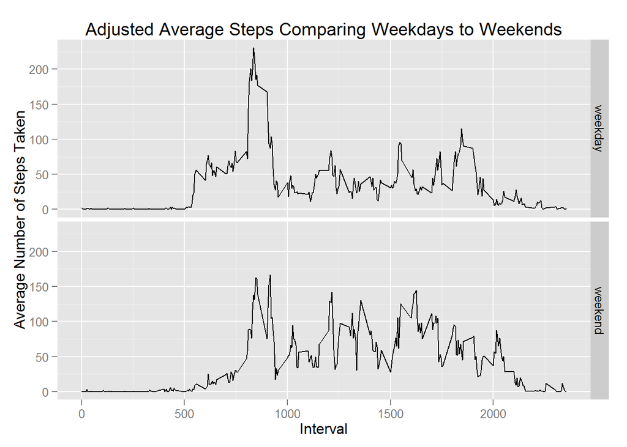

```r
meandataByDay <- dataByDay %>%
            select(steps, interval, day) %>%
            group_by(interval, day) %>%
            summarise(steps = mean(steps))

meandataByDay %>%
            ggplot +
            geom_line(aes(interval, steps)) +
            facet_grid(day ~ .) +
            ggtitle("Adjusted Average Steps Comparing Weekdays to Weekends")+
            xlab("Interval") +
            ylab("Average Number of Steps Taken")
```